# AQ 232 – Fish Population Dynamics and Stock Assessment

The Unit Stock

Nyamisi Peter

2026-01-21

## Introduction

- Fish stock assessment was developed in the temperate regions where there are very few species of fish.
- It was based on a single species
- However, such a consideration is not very applicable for tropical fisheries where we have multi-species fisheries because;
  - Different species are mixed up
  - There is very high interaction among species
- In such situation, fish populations are divided into **stocks (unit stock)** for management and assessment purposes
- Understanding the distribution, abundance, and methods for estimating stock parameters is important for effective stock assessment and sustainable fisheries management.

## Unit Stock

- **A unit stock** is a population of fish, either of a single or different species, grouped together for assessment purposes which may or may not include all the fish in a stock.
- A unit stock is a group of fish that:
  - **Share a common gene pool** – can interbreed
  - **Occupy a defined geographical area** – have a specific distribution
  - **Exhibit similar life history traits** – growth, reproduction, mortality
  - **Are subject to similar fishing pressures** – exploited by the same fisheries
  - **Are managed as a single entity** – for conservation and exploitation, – Can be managed independently from other stocks

## Determination of a Unit Stock

- Unit stocks can be determined through various biological and ecological characteristics, including:
  - Distribution patterns – Where unit stocks are located
  - Spawning behavior – Different stocks spawn in different areas
  - Population parameters – Recruitment, growth and mortality rates, morphometric differences
  - Physiological traits – Temperature at hatching, vertebrae structure, scale decorations, parasite types

## Distribution and Abundance

### Geographic Distribution

- **Geographic distribution** refers to the spatial area where a fish stock is found, including the boundaries of its range.

**Key concepts:**

- Fish populations are not uniformly distributed across all suitable habitats
- Distribution patterns change seasonally (spawning, feeding, wintering areas)
- Some species have discrete distributions while others have overlapping ranges
- Distribution limits are determined by temperature, salinity, bathymetry, and food availability

## Geographic Distribution

**Examples:**

- Migratory species (salmon) move between coastal and riverine habitats
- Demersal species (bottom-dwelling) have specific depth distributions
- Pelagic species distribute widely in open water

**Management implications:**

- Fishing effort should target areas of highest concentration
- Seasonal closures may protect aggregations during vulnerable periods
- International boundaries may complicate management of stocks crossing borders

## Spatial and Temporal Variation in Abundance

**Temporal Variation:**

- **Seasonal changes** - Abundance fluctuates with feeding, spawning, and migration cycles
- **Interannual variation** - Year-to-year changes in recruitment and survival
- **Long-term trends** - Decadal-scale changes related to fishing pressure or environmental conditions

## Spatial and Temporal Variation…

**Spatial Variation:**

- **Patchiness** - Fish concentrate in certain areas (spawning grounds, feeding areas)
- **Gradients** - Density changes across depth, latitude, or habitat types
- **Hotspots** - Areas of consistently high abundance

## Spatial and Temporal Variation…

**Measurement challenges:**

- Detecting aggregations requires spatially intensive sampling
- Small-scale variability requires high sampling effort to quantify accurately
- Temporal dynamics require time series of observations

## Habitat Requirements and Factors Affecting Distribution

**Abiotic Factors:**

- **Temperature** - Most critical factor; thermal preferences vary by species
- **Salinity** - Freshwater, brackish, or marine preferences
- **Dissolved oxygen** - Required for respiration; anaerobic zones are avoided
- **Bathymetry** - Depth preferences related to light and pressure tolerance
- **Substrate type** - Bottom type affects benthic food availability

## Habitat Requirements…

**Biotic Factors:**

- **Food availability** - Distribution follows food resources
- **Predation risk** - Avoidance of predator-rich areas
- **Competition** - Space partitioning with other species
- **Reproductive habitat** - Essential for spawning and nursery grounds

## Habitat Requirements…

**Habitat Quality:**

- Optimal habitat supports higher population densities
- Marginal habitat may be temporarily occupied but has lower reproductive success
- Loss or degradation of critical habitat can limit population size

## Environmental Influences on Stock Distribution

**Physical Oceanography:**

- Ocean currents transport larvae and affect distribution
- Upwelling events create productive feeding areas
- Coastal current patterns structure population distributions

## Environmental Influences…

**Climate and Weather:**

- Climate change shifts suitable habitat ranges
- Seasonal weather events (storms, cold snaps) cause temporary distribution changes
- Long-term climate trends alter distribution boundaries

## Straddling stock and highly migratory fish stock

- With 1982’s United Nations Convention on the Law of the Sea (UNCLOS), coastal nations were given the right to manage fisheries within their Exclusive Economic Zones (EEZ)
- But of course, fish don’t adhere to imaginary lines in the ocean.
- The management of two groups – **straddling and highly migratory fish stocks** became problem after the 1982 Convention.

## Straddling stock

- **Straddling stocks** are fish stocks that migrate across more than one Exclusive Economic Exclusion Zone (EEZ) and the high seas
- - **Straddling stocks** is the stocks of fish which migrate between, or occur in both, the EEZ of one or more states and the high seas
- Fish stocks that migrate through, or occur in more than one exclusive economic zone.
- They include species such as swordfish and marlin.

## Highly migratory fishes

- **Highly migratory fishes** are the ones that travel long distances across international waters
- These include tuna and tuna-like species such as yellowfin tuna, bigeye tuna, and skipjack.

## Management of Straddling stock and Highly migratory fishes

- Management of the straddling stock and highly migratory fishes is a shared responsibility between coastal states and the international community.
- The 1995 United Nations Fish Stocks Agreement (UNFSA), an international treaty designed to further implement provisions of the 1982 Convention which;
  - *Ensure the long-term conservation and sustainable use of straddling fish stocks and highly migratory fish stocks*

## Management…

- Sovereign responsibility must be worked out in collaboration with neighboring coastal states and fishing entities.
- Regional Fisheries Management Organizations (RFMOs) are established to manage these stocks collaboratively.
- **Transboundary stock** range in the EEZs of at least two countries.
- A stock can be both transboundary and straddling.

# Examples from Tanzania Marine Waters

## Tanzanian Exclusive Economic Zone (EEZ)

- Tanzania has an EEZ of approximately **220,000 km²**
- Extends 200 nautical miles from the coastline
- Bordered by Kenya (north), Mozambique (south)
- Manages several important fish stocks
- Home to both regional and international fisheries

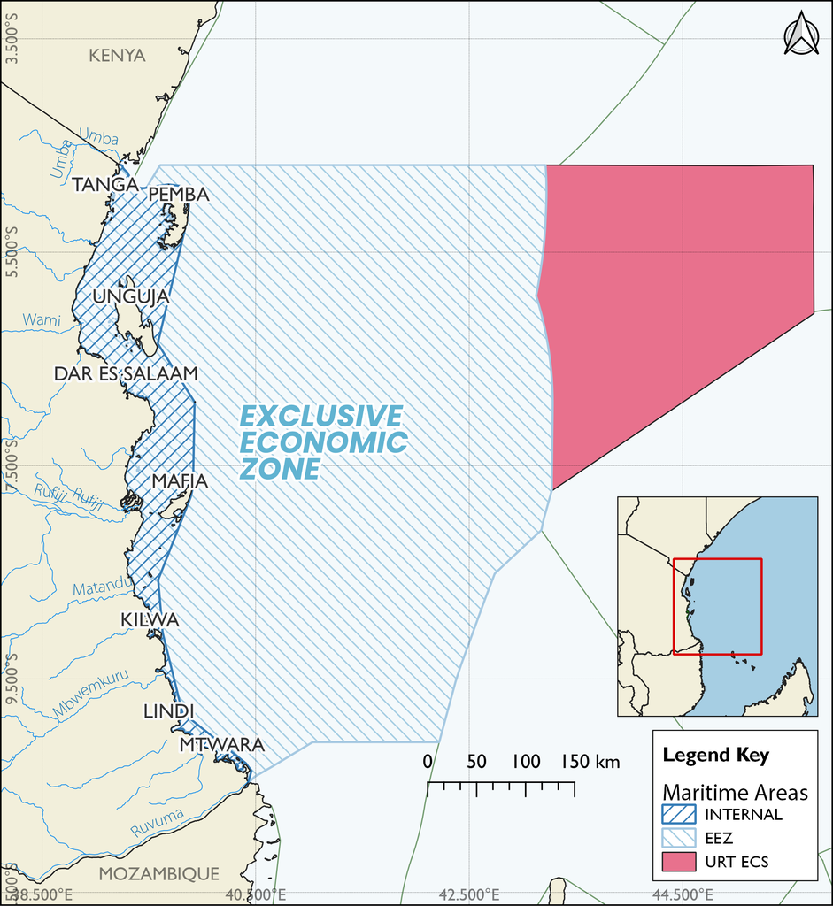

Tanzania marine zones

## 1: Yellowfin Tuna (Highly Migratory)

**Species:** Yellowfin tuna (*Thunnus albacares*)

**Distribution:**

- Found throughout Indian Ocean
- Migrates across multiple EEZs (Tanzania, Kenya, Mozambique, Seychelles)
- Extends beyond EEZs into high seas
- Seasonal movements following monsoon patterns

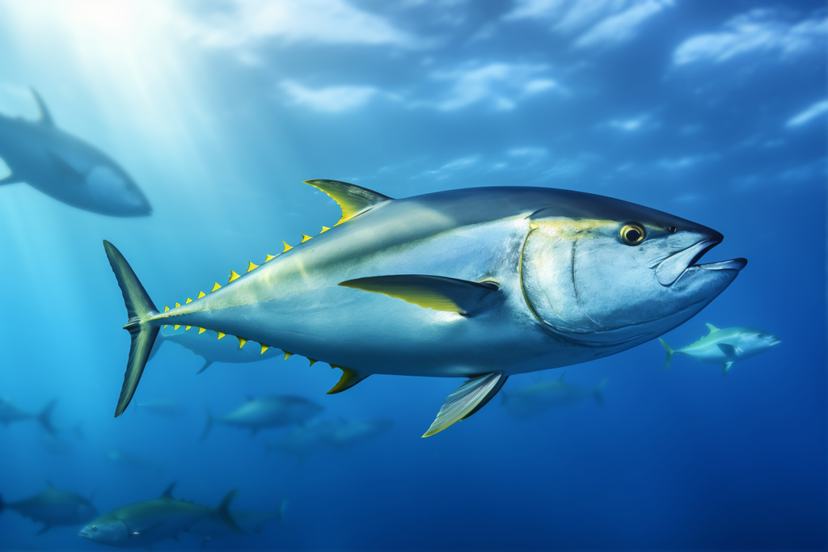

*Thunnus albacares*

## Yellowfin Tuna (Highly Migratory)

**Management:**

- **Managed by IOTC** (Indian Ocean Tuna Commission)
- Tanzania is member state of IOTC
- IOTC sets total allowable catch (TAC) for entire Indian Ocean
- Allocates quota to member countries
- Tanzania receives annual catch quota

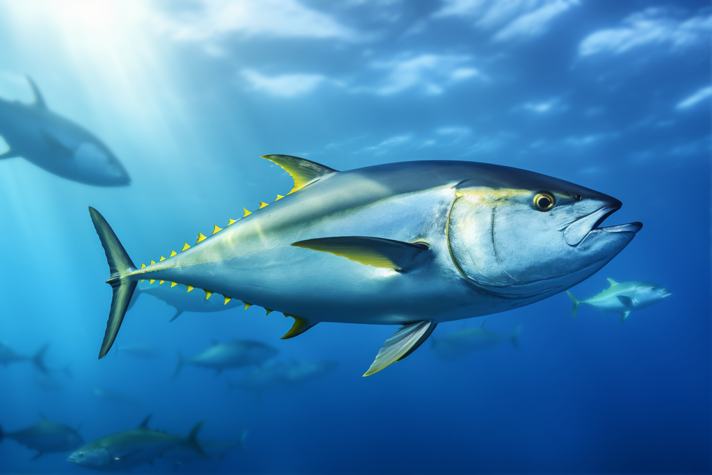

*Thunnus albacares*

## 2: Bigeye Tuna

**Species:** Bigeye tuna (*Thunnus obesus*)

**Distribution:**

- Found in tropical/subtropical Indian Ocean waters
- Deep-diving species (300-400 m daytime depth)
- Migratory across multiple EEZs
- Year-round presence in productive upwelling zones

[figure not shown]

*Thunnus obesus*

## Bigeye Tuna

**Fishery:**

- Caught by longlining (deep hooks target night feeders)
- Tanzania vessels and foreign fleets participate
- Increasing fishing pressure in recent decade

[figure not shown]

*Thunnus obesus*

## Priority Fisheries in Tanzania

Tanzania’s fisheries are strategically important for food security, employment, and economic development. Priority ranking considers:

- Economic value (export revenue)
- Food security contribution (protein supply)
- Employment (fisher livelihoods)
- Management feasibility (data availability)

## Priority Fisheries in Tanzania

- Major priority fishery in Tanzania:

**Marine**

1. Tuna and Tuna-like species (Yellowfin, Bigeye, Skipjack)
2. Small Pelagics (Sardines, Anchovies)
3. Octopus fisheries

**Freshwater**

*Lake Victoria*

1. Nile Perch (*Lates niloticus*)
2. Dagaa (*Rastriger argentea*)

*Lake Tanganyika*

1. **Cichlids** (*Lates stappersii*),
2. **Sardines** (*Stolothrissa tanganicae, Limnothrissa miodon*)

## Mixed stock

- A **mixed stock** occurs when individuals from two or more genetically distinct populations are found together in the same geographic area
- Fish from **multiple spawning populations** intermingle during feeding, migration, or overwintering
- Cannot be easily distinguished visually but are genetically or demographically separate

## Common Scenarios for Mixed Stock

**1. Feeding Aggregations**

- Fish from different spawning stocks congregate in productive feeding grounds
- Example: Salmon from multiple rivers feeding together in the ocean

**2. Migratory Overlap**

- Different populations share migration routes
- Example: Tuna stocks from different ocean regions mixing along migration corridors

**3. Seasonal Mixing**

- Populations separate for spawning but mix at other times
- Example: Herring from different spawning grounds overwintering together

## Mixed Stock: Management Challenges

| Challenge | Implication |
| --- | --- |
| **Identification** | Difficult to assign individuals to source populations |
| **Harvest allocation** | Risk of overfishing weaker stocks while targeting abundant ones |
| **Stock assessment** | Complex models needed to account for mixing rates |
| **Weak stock concern** | Less productive stocks may be depleted if managed as one unit |

## Mixed Stock: Identification Methods

Methods to identify and separate mixed stocks:

- **Genetic markers** (microsatellites)
- **Otolith microchemistry** (trace elements indicate natal origin)
- **Parasite tags** (different parasites in different regions)
- **Morphometric analysis** (body shape differences)
- **Tagging studies** (track individual movements)

## Mixed Stock: Example from East Africa

**Lake Victoria Dagaa** (*Rastrelliger argentea*)

- The dagaa fishery may include mixed stocks from different lake regions
- Fish aggregate in certain areas for feeding
- Different populations have varying productivity levels
- Requires careful management to avoid depleting localized populations

**Indian Ocean Yellowfin Tuna**

- Mixing of stocks from Western and Eastern Indian Ocean
- Genetic studies show population structure across the ocean basin
- IOTC manages as a single stock but monitors regional differences

## References and Further Reading

- Quinn, T. J., & Deriso, R. B. (1999). Quantitative Fish Dynamics. Oxford University Press.
- Hilborn, R., & Walters, C. J. (1992). Quantitative Fisheries Stock Assessment. Chapman & Hall.
- Petitgas, P. (1998). Geostatistics in fisheries survey design and stock assessment. FAO Fisheries Technical Paper 368.

*Last updated: January 2026*